# hw3

## 分析任务 1: 读入数据，查看数据

```r
library(ggplot2)
library(dplyr)
library(ggpubr)

data <- read.csv('/Users/irisjiang/Desktop/data.csv',encoding= 'utf-8')
head(data)
```

```
##   delivery_mode float_delivery_fee float_minimum_order_amount is_new is_premium
## 1      商家配送                  7                          0  False      False
## 2      蜂鸟专送                  5                         20  False       True
## 3      商家配送                  6                         20  False       True
## 4      商家配送                 10                         20  False      False
## 5      商家配送                  7                         30  False      False
## 6      商家配送                  5                         30  False      False
##   order_lead_time recent_order_num compare_rating food_score service_score
## 1              45             2123      0.4948689    4.50012       4.47928
## 2              35             4546      0.7005511    4.61939       4.74763
## 3              51             1194      0.4664587    4.61707       4.47224
## 4              44              375      0.3758566    4.81023       4.70941
## 5              38             6664      0.5331492    4.60685       4.56124
## 6              25               54      0.9563925    4.92060       5.00000
##   star_level district manjian_discount new_user other_activities average_cost
```

[output cut: 27 more lines]

```r
summary(data)
```

```
##  delivery_mode      float_delivery_fee float_minimum_order_amount
##  Length:32043       Min.   :  0.000    Min.   :  0.00
##  Class :character   1st Qu.:  5.000    1st Qu.: 20.00
##  Mode  :character   Median :  7.000    Median : 20.00
##                     Mean   :  8.355    Mean   : 22.87
##                     3rd Qu.:  9.000    3rd Qu.: 20.00
##                     Max.   :200.000    Max.   :500.00
##     is_new           is_premium        order_lead_time recent_order_num
##  Length:32043       Length:32043       Min.   : 0.00   Min.   :    0.0
##  Class :character   Class :character   1st Qu.:26.00   1st Qu.:   45.0
##  Mode  :character   Mode  :character   Median :31.00   Median :  124.0
##                                        Mean   :30.32   Mean   :  465.7
##                                        3rd Qu.:37.00   3rd Qu.:  452.0
##                                        Max.   :80.00   Max.   :13571.0
##  compare_rating      food_score     service_score      star_level
##  Min.   :-1.0000   Min.   :-1.000   Min.   :-1.000   Min.   :-1.000
##  1st Qu.: 0.2792   1st Qu.: 4.341   1st Qu.: 4.401   1st Qu.: 4.400
##  Median : 0.5148   Median : 4.538   Median : 4.643   Median : 4.600
##  Mean   : 0.4472   Mean   : 4.188   Mean   : 4.272   Mean   : 4.237
##  3rd Qu.: 0.7396   3rd Qu.: 4.732   3rd Qu.: 4.834   3rd Qu.: 4.800
##  Max.   : 0.9889   Max.   : 5.000   Max.   : 5.000   Max.   : 5.000
##    district         manjian_discount    new_user     other_activities
##  Length:32043       Min.   :0.0000   Min.   : 0.00   Min.   : 0.0000
##  Class :character   1st Qu.:0.0100   1st Qu.:17.00   1st Qu.: 0.0000
##  Mode  :character   Median :0.1667   Median :20.00   Median : 0.0000
##                     Mean   :0.1975   Mean   :19.16   Mean   : 0.9727
##                     3rd Qu.:0.3231   3rd Qu.:21.00   3rd Qu.: 1.0000
##                     Max.   :0.9583   Max.   :45.00   Max.   :30.0000
##   average_cost          保              票          log_recent_order_num
##  Min.   :     0.0   Mode :logical   Mode :logical   Min.   :0.000
##  1st Qu.:    27.5   FALSE:8359      FALSE:23572     1st Qu.:3.829
##  Median :    38.5   TRUE :23684     TRUE :8471      Median :4.828
##  Mean   :    77.1                                   Mean   :4.758
##  3rd Qu.:    57.6                                   3rd Qu.:6.116
##  Max.   :655873.9                                   Max.   :9.516
##  log_average_cost log_float_minimum_order_amount log_float_delivery_fee
##  Min.   : 0.000   Min.   :0.000                  Min.   :0.000
##  1st Qu.: 3.349   1st Qu.:3.045                  1st Qu.:1.792
##  Median : 3.677   Median :3.045                  Median :2.079
##  Mean   : 3.543   Mean   :2.958                  Mean   :2.101
##  3rd Qu.: 4.070   3rd Qu.:3.045                  3rd Qu.:2.303
##  Max.   :13.394   Max.   :6.217                  Max.   :5.303
##    open_time         open08            open12           open18
##  Min.   : 0.00   Min.   :0.00000   Min.   :0.0000   Min.   :0.0000
##  1st Qu.:10.83   1st Qu.:0.00000   1st Qu.:1.0000   1st Qu.:1.0000
##  Median :11.75   Median :0.00000   Median :1.0000   Median :1.0000
##  Mean   :11.90   Mean   :0.05564   Mean   :0.9621   Mean   :0.9846
##  3rd Qu.:12.50   3rd Qu.:0.00000   3rd Qu.:1.0000   3rd Qu.:1.0000
##  Max.   :24.00   Max.   :1.00000   Max.   :1.0000   Max.   :1.0000
##      open23        shop_type          district0
##  Min.   :0.0000   Length:32043       Length:32043
##  1st Qu.:0.0000   Class :character   Class :character
##  Median :0.0000   Mode  :character   Mode  :character
##  Mean   :0.1536
##  3rd Qu.:0.0000
##  Max.   :1.0000
```

## 分析任务 2: 对数月销量直方图

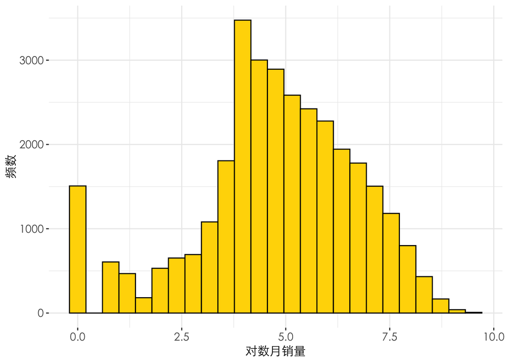

```r
ggplot(data) +
  geom_histogram(aes(x = log_recent_order_num), bins=25, fill = "gold",color='black') +
  labs(y = "频数", x ='对数月销量') +
  theme_bw() +
  theme(panel.border=element_blank(),
        text = element_text(family = "STXihei"),
        axis.title = element_text(size = 12),
        axis.text = element_text(size = 11))
```

总体来看，随着对数月销量的增加，商家数先减后增再减，有大概3500个左右的商家的对数月销量在4左右，占最大比重；有1500左右的商家的对数月销量很小，接近于0。

## 分析任务 3: 行政区划与月销量对比箱线图

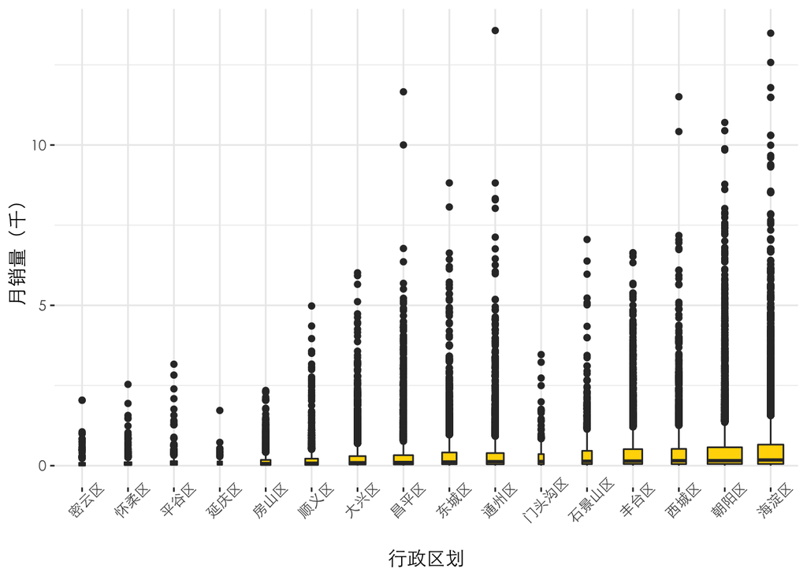

```r
ggplot(data) +
  geom_boxplot(aes(x = reorder(district,recent_order_num,median), y = recent_order_num/1000), varwidth = TRUE, fill = "gold") +
  labs(x = "行政区划", y = "月销量（千）")+
  theme_bw() +
  theme(panel.border=element_blank(),
        text = element_text(family = "STXihei"),
        axis.title = element_text(size = 12),
        axis.text.x = element_text(size = 9,hjust = 0.5,angle=45),
        axis.text.y = element_text(size = 9))
```

从图中我们可以看出，直接用月销量对比各行政区划的箱线图并不直观。但还是可以得到一些基本的特征：城区影响着商家的月销量，城区人口密度越大、城区越发达其商家的月销量也越大。处在海淀区、朝阳区和西城区这三个区属于人口密度较大的市中心城区的商家的月销量的中位数、上四分之一分位数以及最大值都是较大的，而处在密云区、怀柔区、平谷区等人口较少的郊区的商家月销量的中位数等特征普遍较低。从对数月销量来看，整个趋势更加明显：可以看到密云区的下四分之一分位数较其他区低了一大截，处于最低。

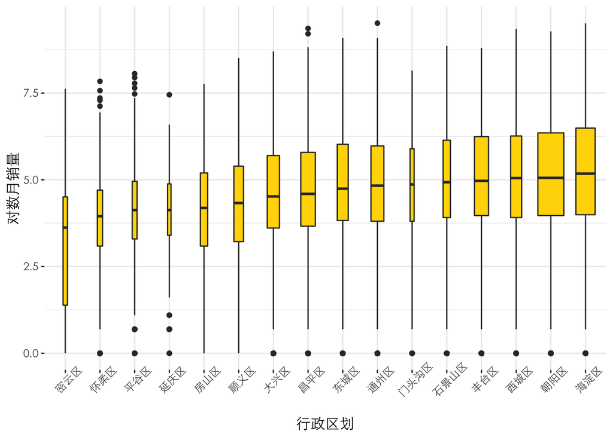

```r
ggplot(data) +
  geom_boxplot(aes(x = reorder(district,log_recent_order_num,median), y = log_recent_order_num), varwidth = TRUE, fill = "gold") +
  labs(x = "行政区划", y = "对数月销量")+
  theme_bw() +
  theme(panel.border=element_blank(),
        text = element_text(family = "STXihei"),
        axis.title = element_text(size = 12),
        axis.text.x = element_text(size = 9,hjust = 0.5,angle=45),
        axis.text.y = element_text(size = 9))
```

## 分析任务 4: 用餐高峰营业情况

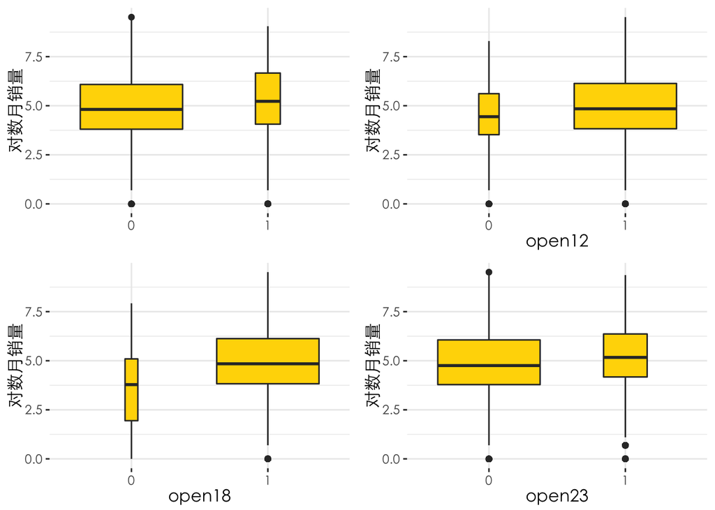

```r
data$open08 <- factor(data$open08)
data$open12 <- factor(data$open12)
data$open18 <- factor(data$open18)
data$open23 <- factor(data$open23)

p1 <- ggplot(data) +
  geom_boxplot(aes(x = open08, y = log_recent_order_num), varwidth = TRUE,fill='gold') +
  labs(x= "",y = "对数月销量")+
  scale_fill_brewer(palette = 1) +
  theme_bw() +
  theme(panel.border=element_blank(),
        text = element_text(family = "STXihei"),
        axis.title = element_text(size = 12),
        axis.text.x = element_text(size = 9),
        axis.text.y = element_text(size = 9))

p2 <- ggplot(data) +
  geom_boxplot(aes(x = open12, y = log_recent_order_num), varwidth = TRUE,fill='gold') +
  labs(y = "对数月销量")+
  scale_fill_brewer(palette = 1) +
  theme_bw() +
  theme(panel.border=element_blank(),
        text = element_text(family = "STXihei"),
        axis.title = element_text(size = 12),
        axis.text.x = element_text(size = 9),
        axis.text.y = element_text(size = 9))

p3 <- ggplot(data) +
  geom_boxplot(aes(x = open18, y = log_recent_order_num), varwidth = TRUE,fill='gold') +
  labs(y = "对数月销量")+
  scale_fill_brewer(palette = 1) +
  theme_bw() +
  theme(panel.border=element_blank(),
        text = element_text(family = "STXihei"),
        axis.title = element_text(size = 12),
        axis.text.x = element_text(size = 9),
        axis.text.y = element_text(size = 9))

p4 <- ggplot(data) +
  geom_boxplot(aes(x = open23, y = log_recent_order_num), varwidth = TRUE,fill='gold') +
  labs(y = "对数月销量")+
  scale_fill_brewer(palette = 1) +
  theme_bw() +
  theme(panel.border=element_blank(),
        text = element_text(family = "STXihei"),
        axis.title = element_text(size = 12),
        axis.text.x = element_text(size = 9),
        axis.text.y = element_text(size = 9))

ggarrange(p1, p2, p3, p4,widths = c(1,1))
```

从图中我们可以看出，总体来说在这四个时间点营业比不营业的商家的对数月销量大一点，特别的事在18点是否营业对于销量产生的差异较大，说明外卖商家的销售主要产生在晚餐的时间点。

## 分析任务 5: BIC准则逐步回归

```r
data$delivery_mode <- factor(data$delivery_mode)
data$is_new <- factor(data$is_new)
data$is_premium <- factor(data$is_premium)
data$保 <- factor(data$保)
data$票 <- factor(data$票)
data$district <- factor(data$district, levels = c("昌平区","朝阳区","海淀区","东城区","丰台区","大兴区",
                                                  "密云区", "平谷区","延庆区","怀柔区","房山区","石景山区",
                                                  "西城区","通州区","门头沟区","顺义区"))
data$shop_type <- factor(data$shop_type, levels = c("果蔬生鲜","快餐简餐","特色菜系","异国料理","小吃夜宵","甜品饮品"))

n <- nrow(data)
model <- lm(log_recent_order_num~log_average_cost+delivery_mode
            +log_float_delivery_fee+log_float_minimum_order_amount
            +order_lead_time+district+保+票+manjian_discount
           +other_activities+new_user+open_time
           +open08+open12+open18+open23+shop_type
           +is_new+is_premium,data=data)
lm.bic <- step(model, direction = "both", k = log(n), trace = T)
```

```
## Start:  AIC=18657.48
## log_recent_order_num ~ log_average_cost + delivery_mode + log_float_delivery_fee +
##     log_float_minimum_order_amount + order_lead_time + district +
##     保 + 票 + manjian_discount + other_activities + new_user +
##     open_time + open08 + open12 + open18 + open23 + shop_type +
##     is_new + is_premium
##
##                                  Df Sum of Sq   RSS   AIC
## - open12                          1       0.0 56658 18647
## - new_user                        1       0.5 56659 18647
## - open08                          1       0.7 56659 18648
## - log_float_minimum_order_amount  1       0.8 56659 18648
## <none>                                        56658 18658
## - open23                          1      22.9 56681 18660
## - 保                              1      37.5 56696 18668
## - open18                          1      47.6 56706 18674
## - delivery_mode                   1     128.9 56787 18720
## - district                       15     513.5 57172 18791
## - open_time                       1     294.3 56953 18813
## - 票                              1     345.8 57004 18842
## - log_float_delivery_fee          1     555.7 57214 18960
## - other_activities                1     747.6 57406 19067
## - shop_type                       5    1696.5 58355 19551
## - is_premium                      1    2141.4 58800 19836
## - log_average_cost                1    2334.7 58993 19941
## - is_new                          1    4642.9 61301 21171
## - order_lead_time                 1    5892.7 62551 21818
## - manjian_discount                1   11193.9 67852 24424
##
## Step:  AIC=18647.12
## log_recent_order_num ~ log_average_cost + delivery_mode + log_float_delivery_fee +
##     log_float_minimum_order_amount + order_lead_time + district +
##     保 + 票 + manjian_discount + other_activities + new_user +
##     open_time + open08 + open18 + open23 + shop_type + is_new +
##     is_premium
##
##                                  Df Sum of Sq   RSS   AIC
## - new_user                        1       0.5 56659 18637
## - open08                          1       0.8 56659 18637
## - log_float_minimum_order_amount  1       0.8 56659 18637
```

[output cut: 86 more lines]

```
## + open12                          1       0.1 56660 18627
## - 保                              1      38.1 56698 18628
## - open18                          1      54.0 56714 18637
## - delivery_mode                   1     130.2 56791 18680
## - district                       15     532.2 57192 18761
## - 票                              1     346.9 57007 18802
## - log_float_delivery_fee          1     564.1 57224 18924
## - open_time                       1     579.6 57240 18933
## - other_activities                1     752.0 57412 19029
## - shop_type                       5    1724.6 58385 19526
## - is_premium                      1    2307.6 58968 19886
## - log_average_cost                1    2345.8 59006 19907
## - is_new                          1    4809.9 61470 21218
## - order_lead_time                 1    5992.7 62653 21828
## - manjian_discount                1   11430.6 68091 24495
```

```r
summary(lm.bic)
```

```
##
## Call:
## lm(formula = log_recent_order_num ~ log_average_cost + delivery_mode +
##     log_float_delivery_fee + order_lead_time + district + 保 +
##     票 + manjian_discount + other_activities + open_time + open18 +
##     open23 + shop_type + is_new + is_premium, data = data)
##
## Residuals:
##     Min      1Q  Median      3Q     Max
## -5.9367 -0.8157  0.0620  0.9003  4.3921
##
## Coefficients:
##                          Estimate Std. Error t value Pr(>|t|)
## (Intercept)             0.5631725  0.0857889   6.565 5.30e-11 ***
## log_average_cost        0.2668911  0.0073315  36.403  < 2e-16 ***
## delivery_mode蜂鸟专送  -0.1640758  0.0191332  -8.575  < 2e-16 ***
## log_float_delivery_fee -0.3102244  0.0173775 -17.852  < 2e-16 ***
## order_lead_time         0.0386588  0.0006644  58.184  < 2e-16 ***
## district朝阳区          0.0345394  0.0294999   1.171  0.24167
## district海淀区          0.0104325  0.0316719   0.329  0.74186
## district东城区         -0.1260826  0.0427856  -2.947  0.00321 **
## district丰台区          0.0371510  0.0364244   1.020  0.30776
## district大兴区         -0.0314157  0.0393380  -0.799  0.42452
## district密云区         -0.5858945  0.0864320  -6.779 1.23e-11 ***
## district平谷区         -0.0640392  0.0806954  -0.794  0.42744
## district延庆区          0.1195407  0.1086993   1.100  0.27145
## district怀柔区         -0.3024593  0.0753948  -4.012 6.04e-05 ***
## district房山区         -0.3978019  0.0550011  -7.233 4.84e-13 ***
## district石景山区        0.0839381  0.0547053   1.534  0.12495
## district西城区         -0.0544237  0.0422201  -1.289  0.19739
## district通州区          0.2839959  0.0373852   7.596 3.13e-14 ***
## district门头沟区        0.2970940  0.0915206   3.246  0.00117 **
## district顺义区         -0.1842610  0.0445789  -4.133 3.58e-05 ***
## 保TRUE                  0.1101934  0.0237518   4.639 3.51e-06 ***
## 票TRUE                  0.2635722  0.0188281  13.999  < 2e-16 ***
## manjian_discount        3.9118711  0.0486803  80.358  < 2e-16 ***
## other_activities        0.0930431  0.0045140  20.612  < 2e-16 ***
## open_time               0.0610309  0.0033728  18.095  < 2e-16 ***
## open181                 0.3536137  0.0640169   5.524 3.34e-08 ***
## open231                 0.1109112  0.0270153   4.105 4.04e-05 ***
## shop_type快餐简餐       0.9234872  0.0397257  23.247  < 2e-16 ***
## shop_type特色菜系       0.4506565  0.0407715  11.053  < 2e-16 ***
## shop_type异国料理       0.6365183  0.0472139  13.482  < 2e-16 ***
## shop_type小吃夜宵       0.7420333  0.0412015  18.010  < 2e-16 ***
## shop_type甜品饮品       0.4407513  0.0471023   9.357  < 2e-16 ***
## is_newTrue             -1.4763716  0.0283226 -52.127  < 2e-16 ***
## is_premiumTrue          0.9139038  0.0253116  36.106  < 2e-16 ***
## ---
## Signif. codes:  0 '***' 0.001 '**' 0.01 '*' 0.05 '.' 0.1 ' ' 1
##
## Residual standard error: 1.33 on 32009 degrees of freedom
## Multiple R-squared:  0.5346, Adjusted R-squared:  0.5341
## F-statistic:  1114 on 33 and 32009 DF,  p-value: < 2.2e-16
```

根据BIC准则逐步回归后，最终模型中包含的自变量为对数平均每单费用(log_average_cost)、配送模式(delivery_mode)、对数配送费(log_float_delivery_fee)、配送时间(order_lead_time)、行政区划1(district)、是否有外卖保(保)、是否开发票(票)、满减折扣率(manjian_discount)、其他优惠活动数(other_activities)、每天营业时长(open_time)、18点是否营业(open18)、23点是否营业(open23)、商家分类(shop_type)、是否新店(is_new)、是否品牌店(is_premium)。其中，行政区划变量以昌平区为基准，商家分类变量以果蔬生鲜为基准。

除去行政区划变量和商店分类变量，从各个变量系数来看，对数平均每单费用、配送时间、支持外卖保和提供发票、满减及其他优惠活动、营业时间、在18和23点营业以及成为品牌店都与商家的对数月销量呈正相关，对月销量有促进作用，且在其他变量相等的情况下，品牌店的销量要高于非品牌店。在所有正相关的自变量中，满减折扣率的系数最大。与之相反的是，配送模式、对数配送费、新店都与对数月销量呈负相关，且在其他变量相等的情况下，新店的销量要低于老店。在所有负相关的自变量中，是否是新店的系数绝对值最大。除去行政区划变量之外的所有变量均在99%的置信水平下显著。

对于各个行政区来说，以昌平区为基准水平，在其他变量相等的情况下，朝阳、海淀、丰台、延庆、石景山、通州和门头沟区的月销量会高于昌平，其余区则会低于昌平。在行政区划变量中，东城、密云、怀柔、房山、通州、门头沟和顺义均在99%的置信水平下显著。

对于商家分类来说，以果蔬生鲜为基准，在其他变量相等的情况下，其他五种类别的商家月销量都会高于果蔬生鲜。

## 分析任务 6: 系数柱状图

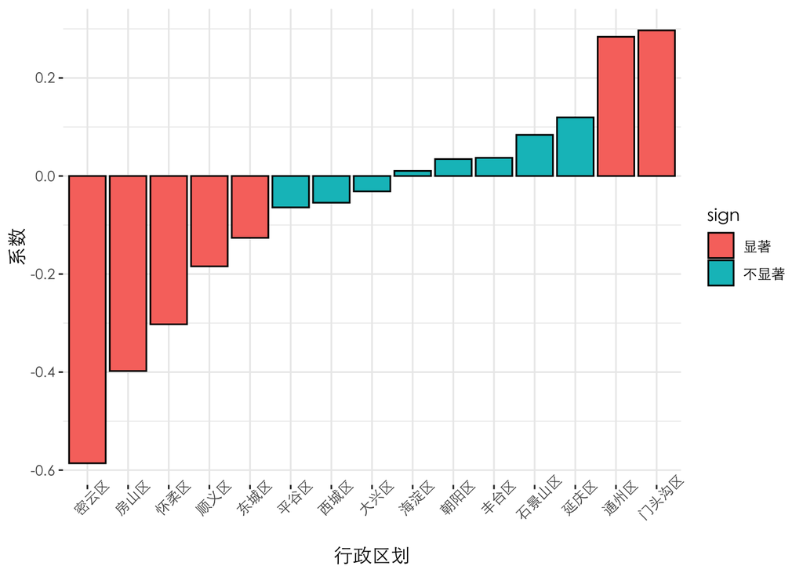

```r
coef = lm.bic$coefficients
district_coef = data.frame(coef[6:20])
colnames(district_coef) = 'coef'
district_coef['district'] = c("朝阳区","海淀区","东城区","丰台区","大兴区",
                              "密云区", "平谷区","延庆区","怀柔区","房山区","石景山区",
                              "西城区","通州区","门头沟区","顺义区")
district_coef['sign'] = '1'
district_coef[c(1,2,4,5,7,8,11,12),'sign'] = '0'
district_coef$sign = factor(district_coef$sign,
                            levels =c('1','0'),
                            labels = c("显著","不显著"))
ggplot(district_coef)+
  geom_bar(stat="identity",aes(x=reorder(district,coef),y = coef,fill = sign),color='black')+
  labs(x="行政区划",y = "系数")+
  theme_bw() +
  theme(panel.border=element_blank(),
        text = element_text(family = "STXihei"),
        axis.title = element_text(size = 12),
        axis.text.x = element_text(size = 9,hjust = 0.5,angle=45),
        axis.text.y = element_text(size = 9))
```

如图，从模型中提取出行政区变量的系数与显著性并绘制系数柱状图，回归系数按数值大小排列，显著为橙色，不显著为蓝色。

## 分析任务 7: 预测

```r
model_sub <- lm(log_recent_order_num ~ log_average_cost +delivery_mode+district+shop_type
                                  +log_float_delivery_fee+order_lead_time+票
                                  +manjian_discount+other_activities+new_user
                                 +open_time+open18+open23+is_new+is_premium
          +compare_rating,data=data)

summary(model_sub)
```

```
##
## Call:
## lm(formula = log_recent_order_num ~ log_average_cost + delivery_mode +
##     district + shop_type + log_float_delivery_fee + order_lead_time +
##     票 + manjian_discount + other_activities + new_user + open_time +
##     open18 + open23 + is_new + is_premium + compare_rating, data = data)
##
## Residuals:
##     Min      1Q  Median      3Q     Max
## -5.7857 -0.7568  0.0516  0.8246  4.1957
##
## Coefficients:
##                          Estimate Std. Error t value Pr(>|t|)
## (Intercept)             1.0534936  0.0886578  11.883  < 2e-16 ***
## log_average_cost        0.0389157  0.0074236   5.242 1.60e-07 ***
## delivery_mode蜂鸟专送  -0.0976272  0.0161076  -6.061 1.37e-09 ***
## district朝阳区          0.0516573  0.0270566   1.909 0.056241 .
## district海淀区          0.0306336  0.0290984   1.053 0.292459
## district东城区         -0.1391647  0.0392582  -3.545 0.000393 ***
## district丰台区          0.0267269  0.0335018   0.798 0.425007
## district大兴区         -0.0522870  0.0362336  -1.443 0.149016
## district密云区         -0.5106768  0.0826707  -6.177 6.60e-10 ***
## district平谷区         -0.0603034  0.0784059  -0.769 0.441829
## district延庆区          0.1148447  0.1040424   1.104 0.269677
## district怀柔区         -0.2682834  0.0735454  -3.648 0.000265 ***
## district房山区         -0.3731264  0.0507292  -7.355 1.95e-13 ***
## district石景山区        0.1206910  0.0504688   2.391 0.016790 *
## district西城区         -0.0370554  0.0387861  -0.955 0.339393
## district通州区          0.2634771  0.0344865   7.640 2.23e-14 ***
## district门头沟区        0.3586001  0.0844338   4.247 2.17e-05 ***
## district顺义区         -0.1752427  0.0411106  -4.263 2.03e-05 ***
## shop_type快餐简餐       0.7002123  0.0339296  20.637  < 2e-16 ***
## shop_type特色菜系       0.3286344  0.0350410   9.379  < 2e-16 ***
## shop_type异国料理       0.4019912  0.0422413   9.517  < 2e-16 ***
## shop_type小吃夜宵       0.4605938  0.0362396  12.710  < 2e-16 ***
## shop_type甜品饮品       0.0756402  0.0417099   1.813 0.069767 .
## log_float_delivery_fee -0.2763664  0.0159898 -17.284  < 2e-16 ***
## order_lead_time         0.0326416  0.0006167  52.929  < 2e-16 ***
## 票TRUE                  0.2662845  0.0173299  15.366  < 2e-16 ***
## manjian_discount        3.7130748  0.0451610  82.219  < 2e-16 ***
## other_activities        0.0965321  0.0041647  23.178  < 2e-16 ***
## new_user                0.0039730  0.0021687   1.832 0.066964 .
## open_time               0.0577711  0.0031056  18.602  < 2e-16 ***
## open181                 0.2788190  0.0590090   4.725 2.31e-06 ***
## open231                 0.1563308  0.0246707   6.337 2.38e-10 ***
## is_newTrue             -0.5904099  0.0289980 -20.360  < 2e-16 ***
## is_premiumTrue          0.7789267  0.0240086  32.444  < 2e-16 ***
## compare_rating          1.5444680  0.0205878  75.018  < 2e-16 ***
## ---
## Signif. codes:  0 '***' 0.001 '**' 0.01 '*' 0.05 '.' 0.1 ' ' 1
##
## Residual standard error: 1.227 on 32008 degrees of freedom
## Multiple R-squared:  0.6039, Adjusted R-squared:  0.6035
## F-statistic:  1436 on 34 and 32008 DF,  p-value: < 2.2e-16
```

```r
pred_data = data.frame(log_average_cost=log(21),
                      delivery_mode='蜂鸟专送',
                      district = "海淀区",
                      shop_type = "快餐简餐",
                      log_float_delivery_fee=log(7),
                      order_lead_time=45,
                      票=factor(FALSE),
                      manjian_discount=0.35,
                      other_activities=5,
                      new_user=0,
                      open_time=11,
                      open18=factor(1),
                      open23=factor(1),
                      is_new=factor('False'),
                      is_premium=factor('False'),
                      compare_rating=0.65)

pred <- exp(predict(model_sub, pred_data)-1)
pred
```

```
##        1
## 268.5539
```

假设北京与长宁区定位相似的行政区为海淀区，那么将题目中提到的变量作为自变量建立模型并对对数月销量进行回归，再基于该模型根据具体取值进行回归，可以得到预测的月销量为268单。